# Exploration for Data Filtering

Anna Steel

August 10, 2016

### Read in Data

- Open script from Fremont16.Rproj in GitHub to ensure directories are correct
- Creates basic df as well as projects a spatial dataframe
- currently unable to reproject into UTM; emailed Frank Smith @ VEMCO 8/11/2016
- result is that the latlong are in WGS84 and the XY are azimuthal. Which is exactly what it says in the 2015 report. nice.

```
## [1] "Prior to filtering, 130665 total posotions in dataset"
```

```
## [1] "Prior to filtering, 438 inidividual fish positioned"
```

### Initial Data Cleaning

- remove exessively high HPEs (<1000) for ease later
- reduce dataset to only postions recorded after full VPS array was in place (don’t yet have removal dates, so not incorporated here)
- other steps to include here?

```
## [1] "Removing 0 positions with HPEs > 1000"
```

```
## [1] "0 positions removed due to incomplete VPS array"
```

### Explore HPEs relationship with measured error for sync and reference tags

- Only positions with Hpes<1000
- Currently uses Heversine formula with earth’s radius est = 6371 km to calc distance between lat-long coords
- Eventually would like to first convert to UTM to faciliate calculating distances between points
- actually, silly girl, use the XY coordinates already in here. Wow.

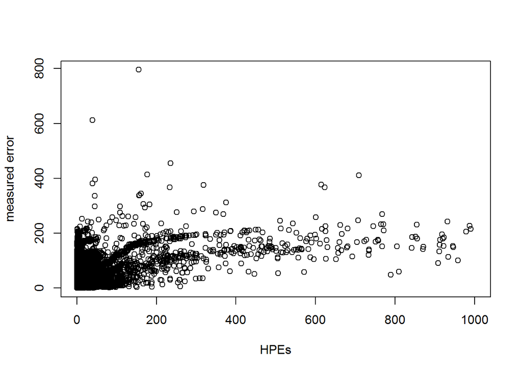

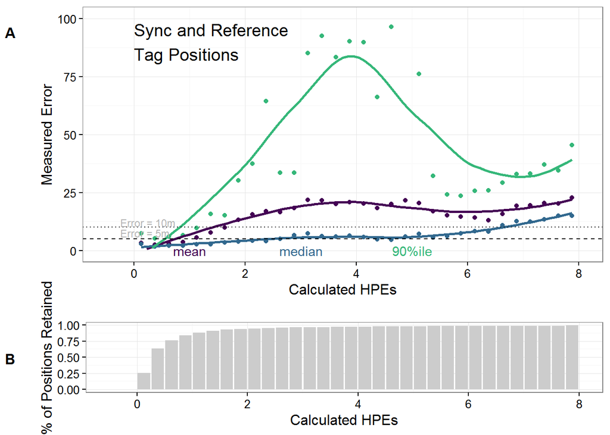

```
## [1] "At threshold of HPEs<1, mean measured error (m) of sync/ref positions = 2.91"
```

```
## [1] "At threshold of HPEs<1, median measured error (m) of sync/ref positions = 2.1"
```

```
## [1] "At threshold of HPEs<1, 90%ile of measured error (m) of sync/ref positions = 5.64"
```

```
## [1] "At threshold of HPEs<1, 83.72% of sync/ref positions retained"
```

Based on these graphics I will use a HPE filtering threshold of HPE=1; this seems to be a nice tradeoff between precision (mean ~ 5m in HPE bin 0.75-1) and quantity of data (~80% of data retained).

- Eventually will project remaining and removed positions into spatial data to make maps cleaner and integrate river bank
- currently, the reprojection from VEMCO’s aeqd is not working (see above)

### Implement HPEs threshold in filtering

- This DOES NOT match the report from VEMCO (they report 106,529 or 87% after filtering to HPE<1)
- I need to get the tagID metadata from someone; suspect there are tags here that aren’t fish tags

```
## [1] "After filtering @ HPEs<1, dataset retained:"
```

```
## [1] "  110211 positions,"
```

```
## [1] "  84.35% of fish tag positions"
```

```
## [1] "  438 individual fish"
```

Here is an excerpt from VEMCO’s results document that is returned with the post-processed VPS dataset, regarding thier estimate of the precision of the fish positions:

> Fish tag precision is estimated here using a simple method of comparing pairs of calculated positions that are very close in time, based on the knowledge that over a short period of time a fish will travel a relatively short distance. The time durations between successive transmissions of a fish tag in this study follow a pseudorandom sequence, with a minimum of 1.0 seconds, a maximum of 2.0 seconds, and an average of 1.5 seconds. For each of the HPEs filters, the retained positions are analyzed as follows: • Pairs of positions from the same transmitter that are within 2.0 seconds of each other are identified, and the horizontal distances between these pairs of positions are calculated • Selected percentiles of these horizontal distances are calculated The following is a summary of these analyses: HPEs # Pos % pos 50%ile 80%ile 90%ile 95%ile 0.2 25792 21% 1.34 2.04 2.56 3.16 0.5 83658 68% 1.57 2.54 3.45 4.62 1.0 106529 87% 1.68 2.93 4.21 5.86 For example, using an HPEs filter of 1.0, half of the pairs of calculated positions that are within 2.0 seconds of each other are less than 1.68 metres apart, and 80% are within 2.93m. Note that these statistics cannot be compared directly with the corresponding statistics for sync and reference tags because they include a component based on an average of 1.5 seconds of fish motion.

### Distributions of individual detections/GoodBasic positions for each calculated fish location:

- not of much interest but code was already written

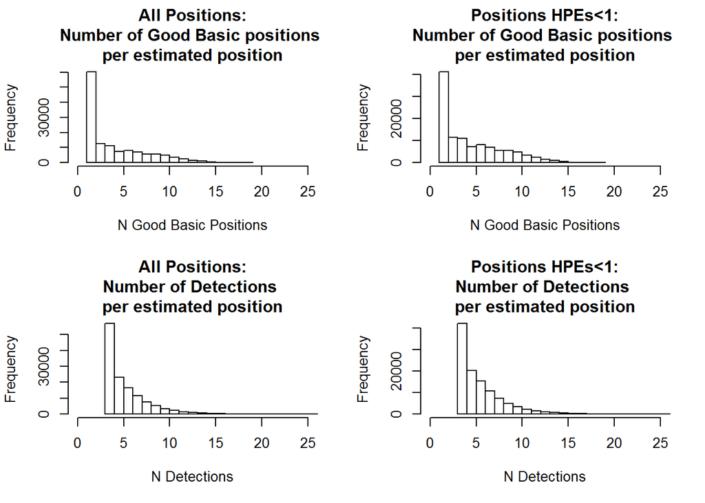

### Positions remaining per fish (Figs 8 and 10 in 2015 report)

```
##           Min.        1st Qu.         Median           Mean        3rd Qu.
##    7.000000000  183.000000000  237.500000000  298.310502283  316.000000000
##           Max.
## 7647.000000000
```

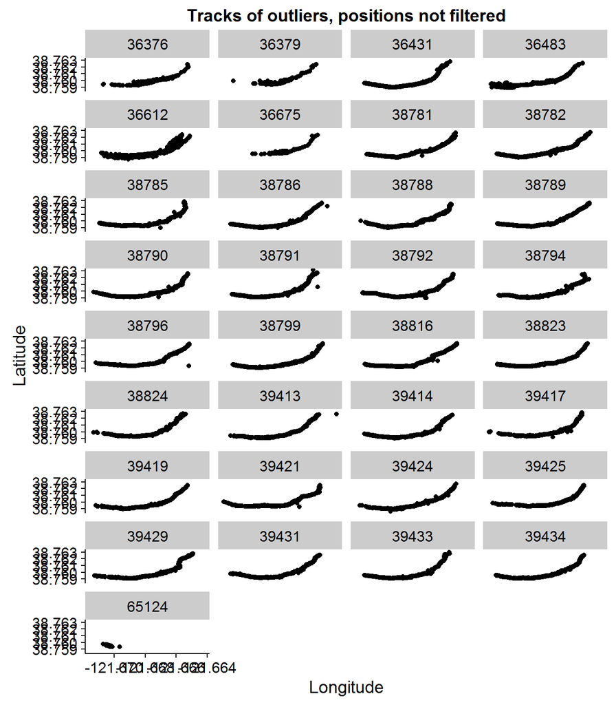

```
##           Min.        1st Qu.         Median           Mean        3rd Qu.
##    6.000000000  164.000000000  211.000000000  251.623287671  283.000000000
##           Max.
## 3646.000000000
```

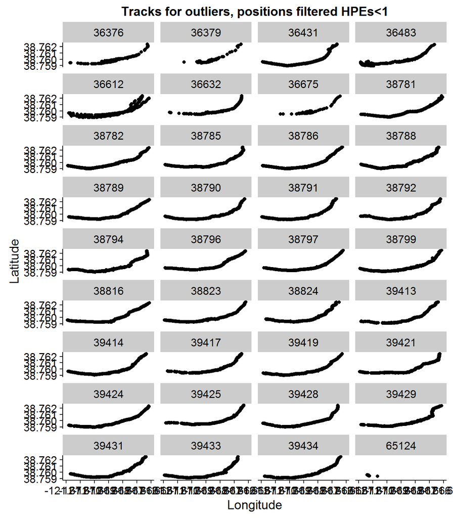

### Look at fish which >40% positions removed

- how many are there?
- are the tracks indicative of predator behavior?
- where are the errors?

```
## [1] "Only 2 fish with >40% of positions removed"
```

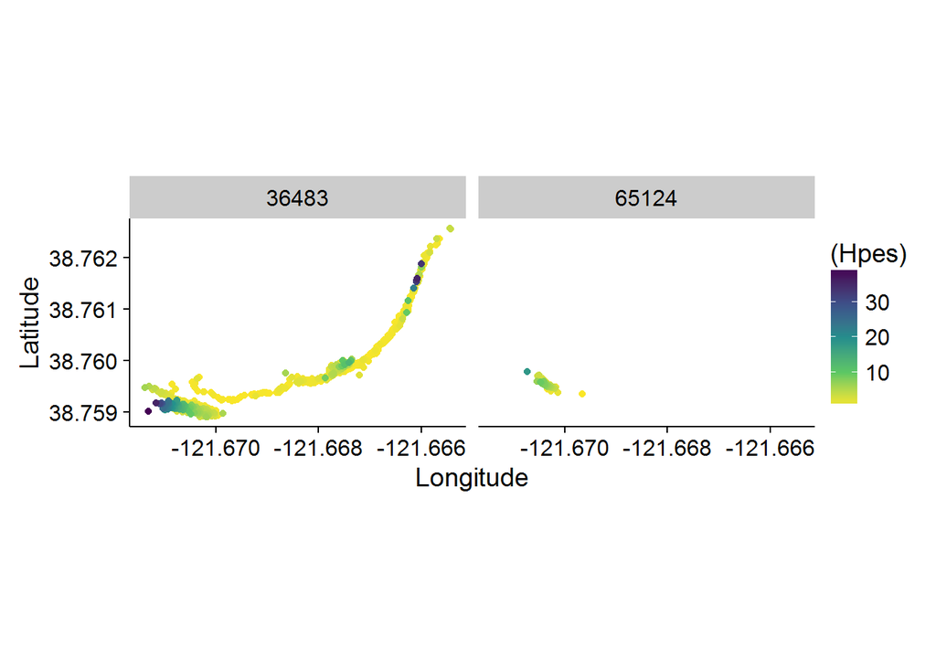

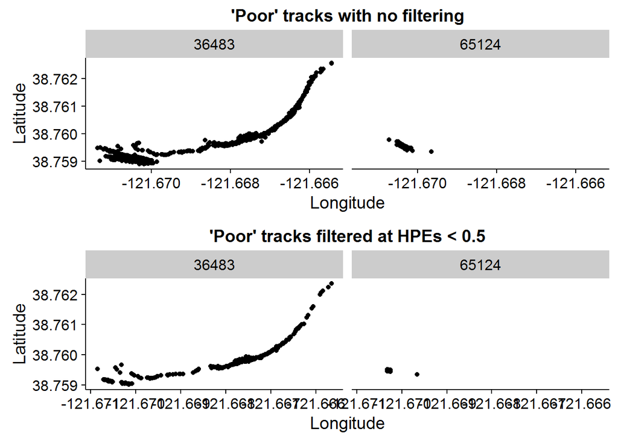

### Look at fish tracks for potential predators

- high number of detections
- 1st plot shows tracks for fish with the top 5% of recorded positions
- long passage time
- movement upstream

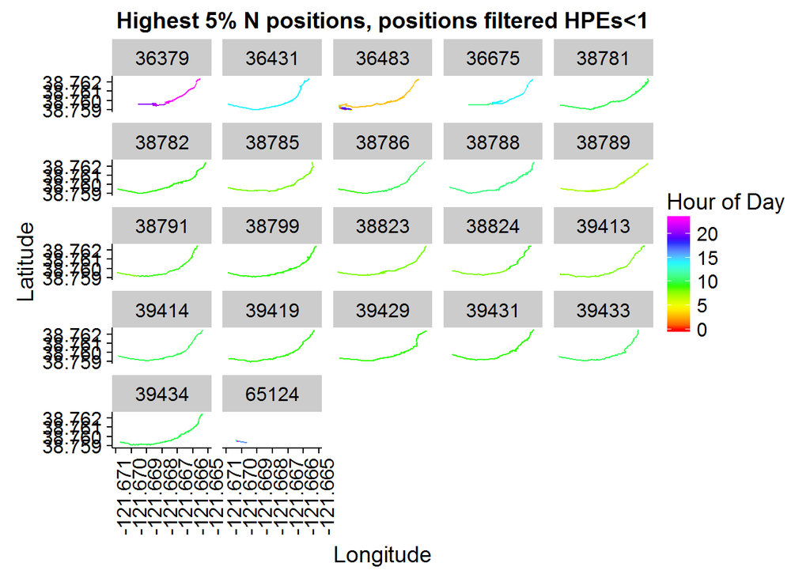

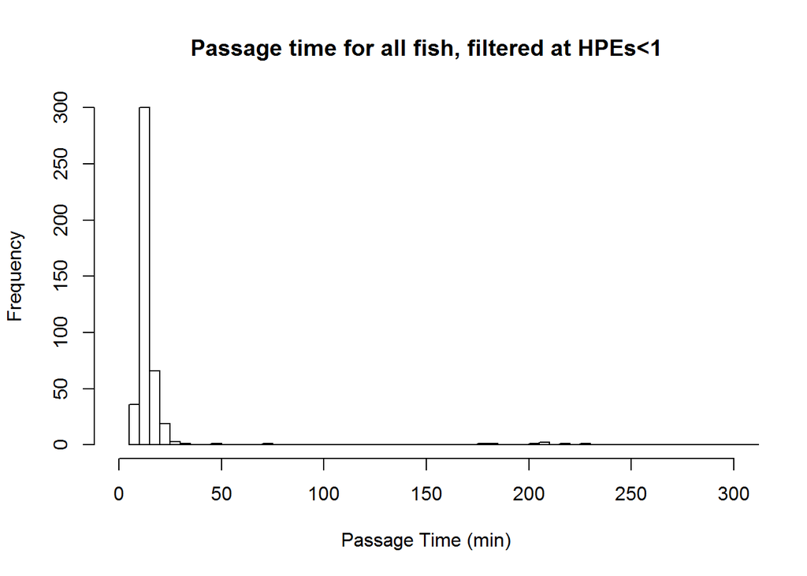

```
## [1] "11 individual tags with >150 min passage time"
```

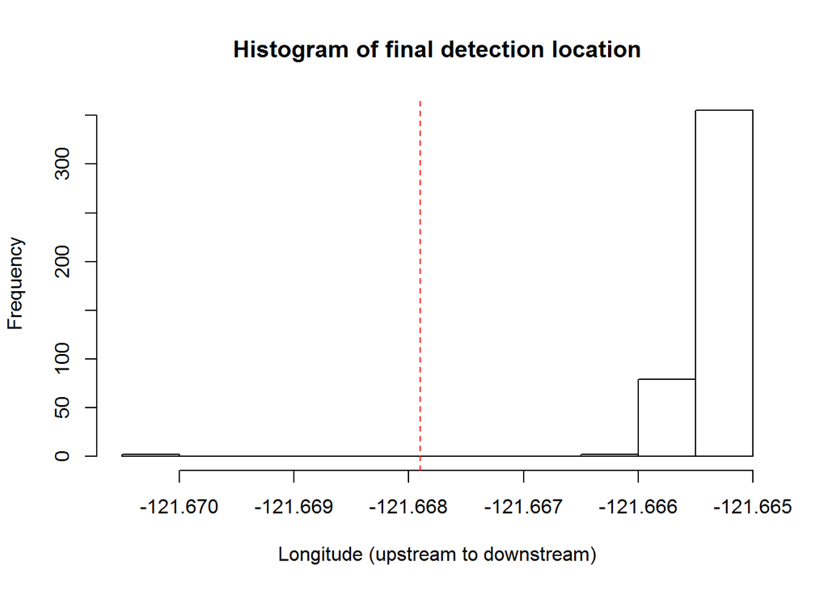

```
## [1] "2 fish exited at upstream end of array"
```